# index

# **Minorías masculinas en pedagogía: Un estudio de las trayectorias académicas de hombres en Chile (2007–2024)**

En este documento se presenta un conjunto de visualizaciones elaboradas para profundizar en algunos de los principales resultados obtenidos a lo largo del estudio. Su objetivo es ofrecer una exploración visual de la información empírica, permitiendo examinar patrones, tendencias y relaciones que, por restricciones de formato, no pudieron desarrollarse en el póster.

A través de gráficos y otras representaciones visuales, se busca facilitar la lectura de los resultados y apoyar su discusión, aportando mayor detalle descriptivo y comparativo sobre los fenómenos analizados. En este sentido, el documento opera como un complemento al material presentado en el congreso, orientado a enriquecer la comprensión de los hallazgos sin introducir análisis adicionales ni resultados nuevos.

Dado que el trabajo se encuentra en proceso de publicación, el contenido se limita a salidas gráficas seleccionadas y no incluye insumos que permitan la reproducción íntegra del análisis

## **Base 1 DEMRE**

La etapa de acceso se analiza a partir de 125.546 registros de postulación correspondientes a personas que, en alguna de sus preferencias, seleccionaron un programa de pedagogía en educación parvularia o básica. De este total, 20.285 registros corresponden a hombres y 105.261 a mujeres.

### Figura 1

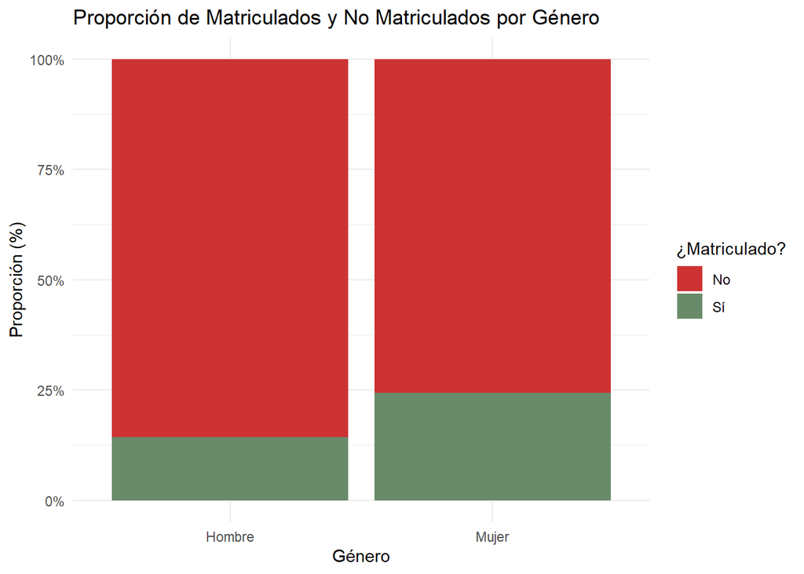

### Figura 2

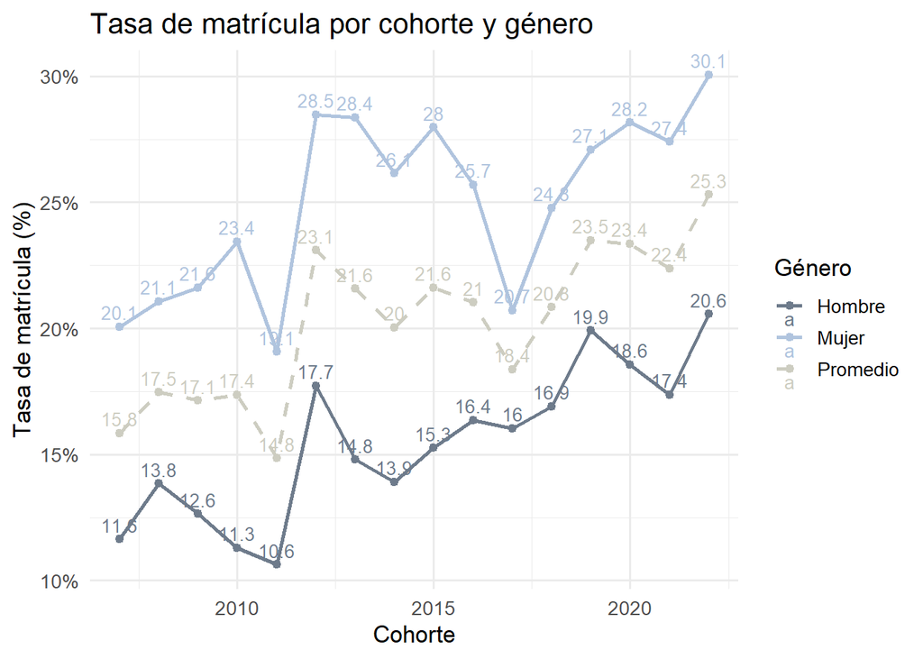

### **Figura 3**

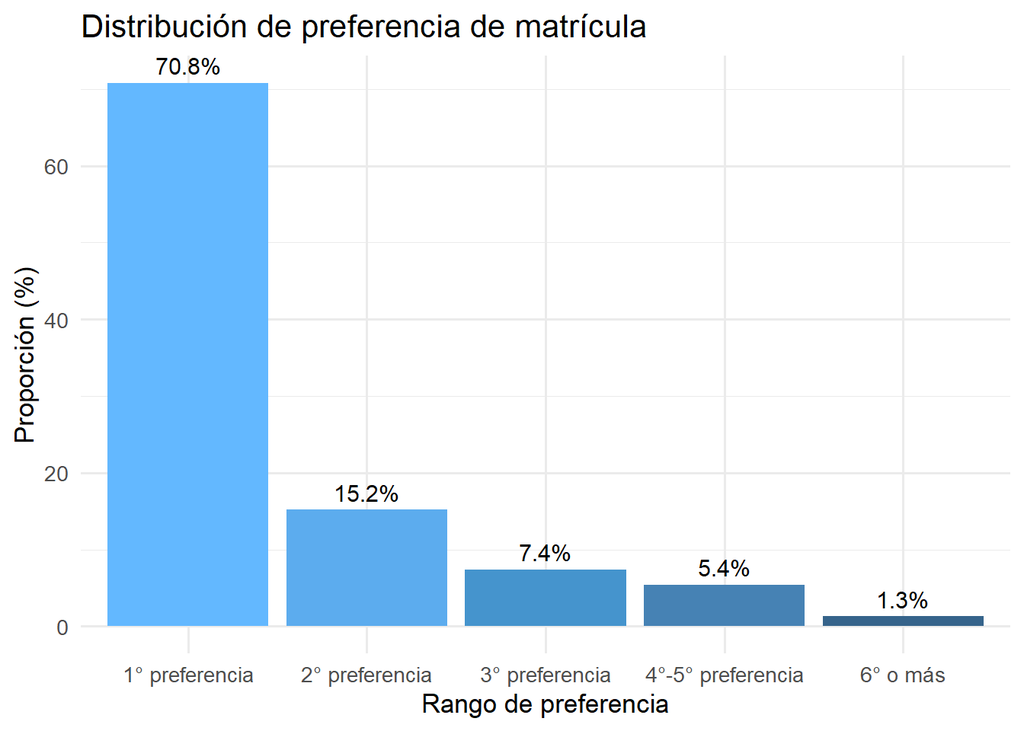

### Figura 4

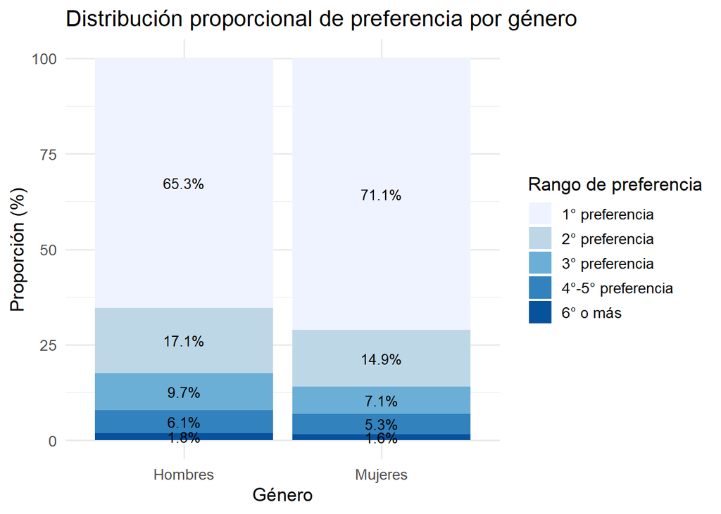

### Tabla 1

Cantidad de rendiciones que realizan los postulantes separado por género

```
# A tibble: 2 × 3
  Género promedio_rendiciones desviacion_rendiciones
  <chr>                 <dbl>                  <dbl>
1 Hombre                 1.90                  1.03
2 Mujer                  1.74                  0.873
```

### Figura 5

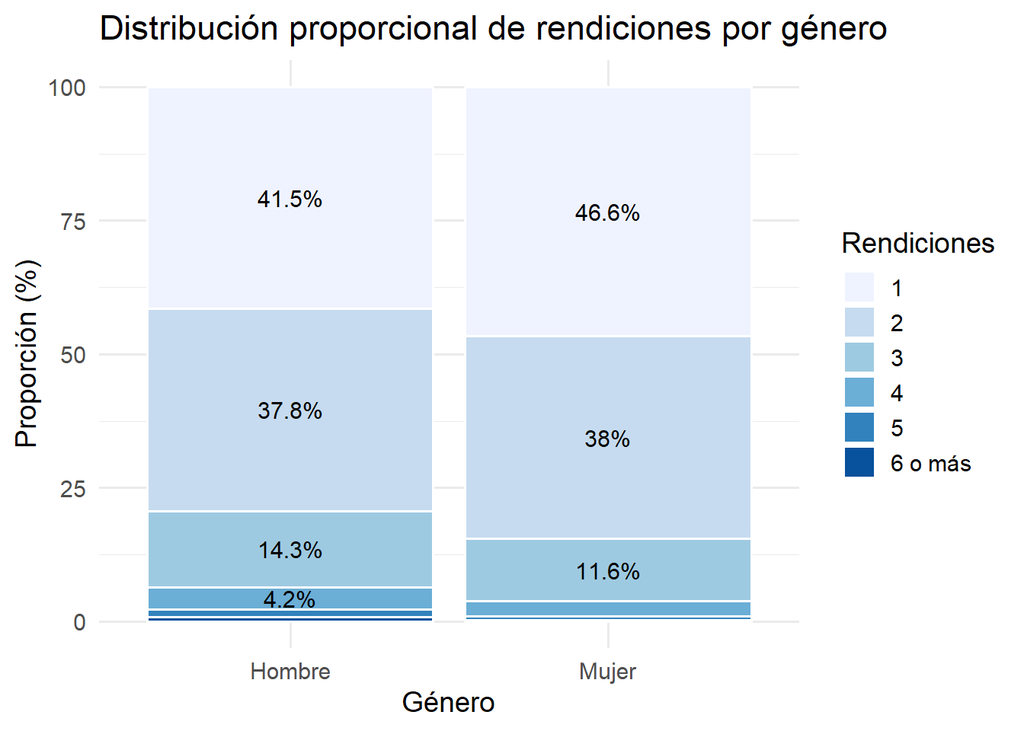

### Figura 6

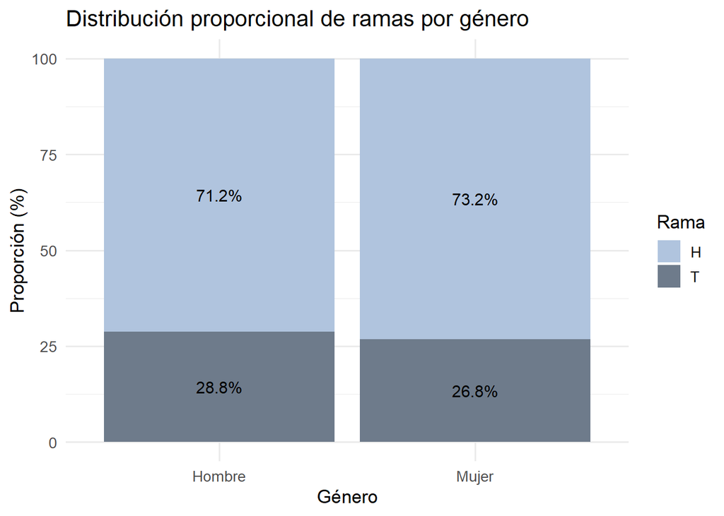

### Figura 7

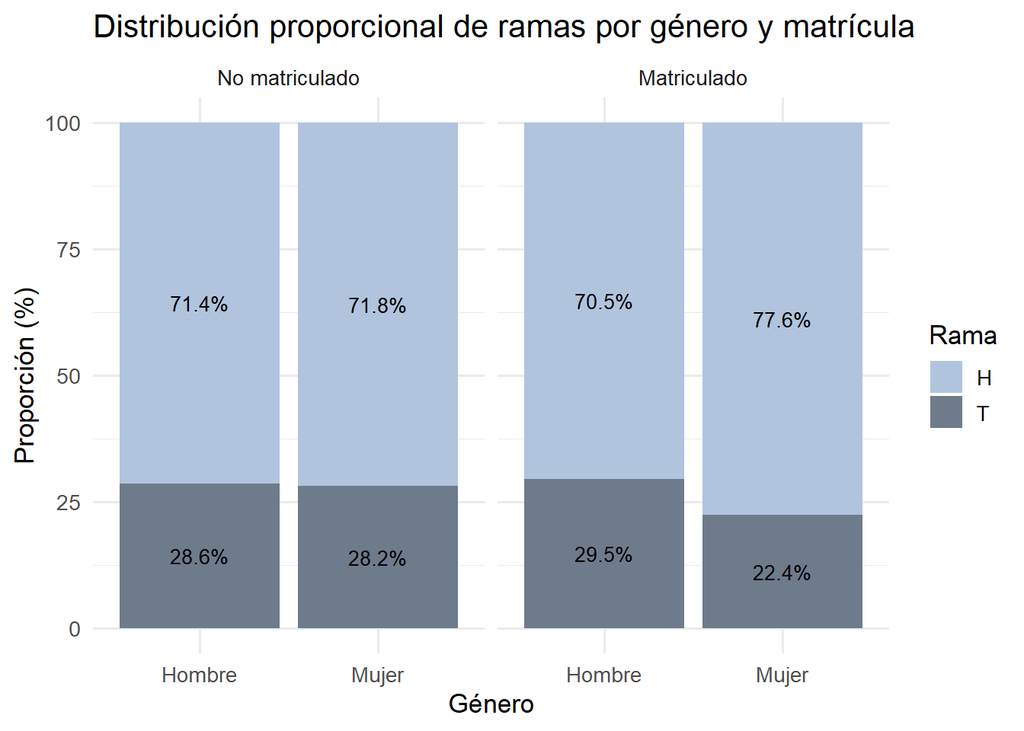

### Figura 8

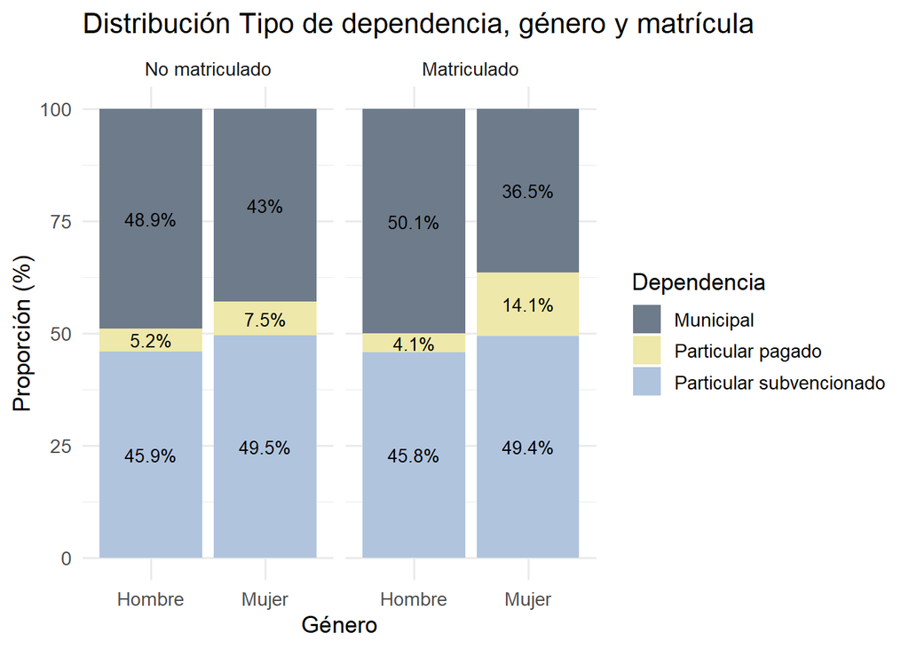

## Base 2 MINEDUC educación superior

El conjunto de matrículas registradas en programas de pedagogía en educación parvularia y básica asciende a 334.875 eventos durante el período analizado. De ellos, 305.978 corresponden a mujeres y 28.897 a hombres.

### Figura 9

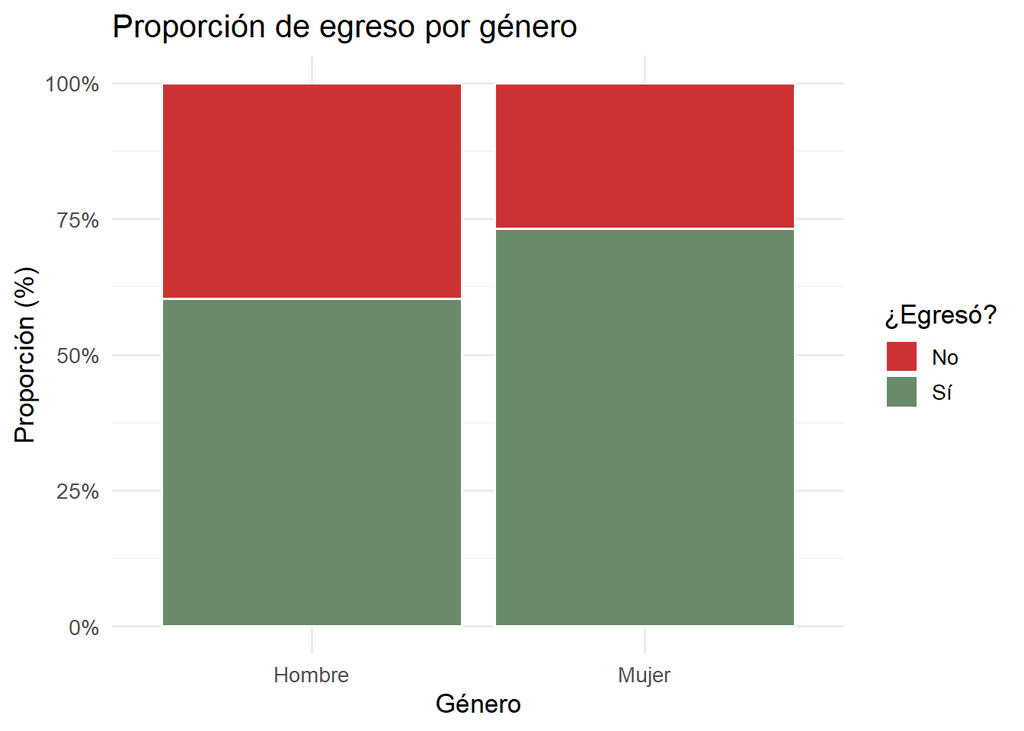

### Figura 10

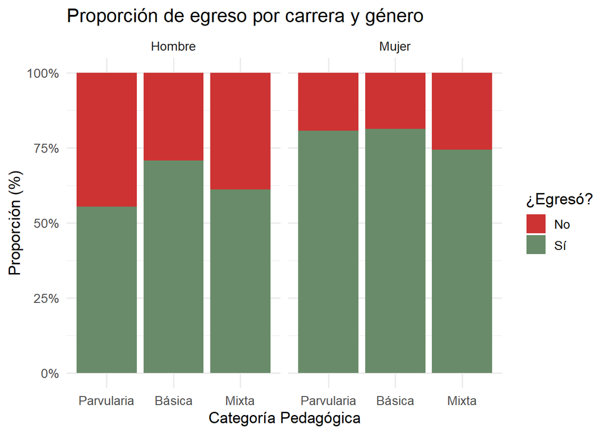

### Figura 11

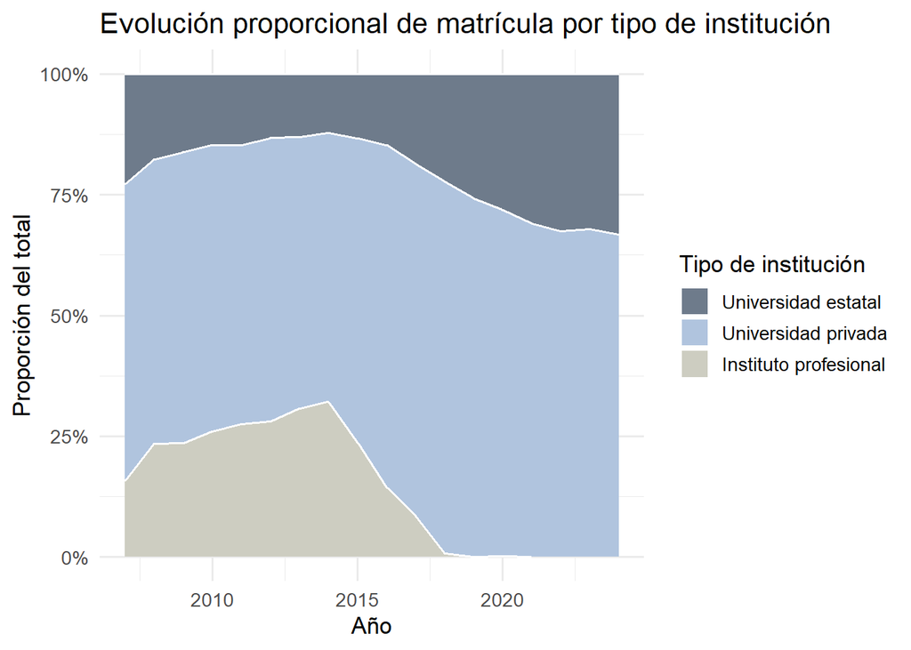

### Figura 12

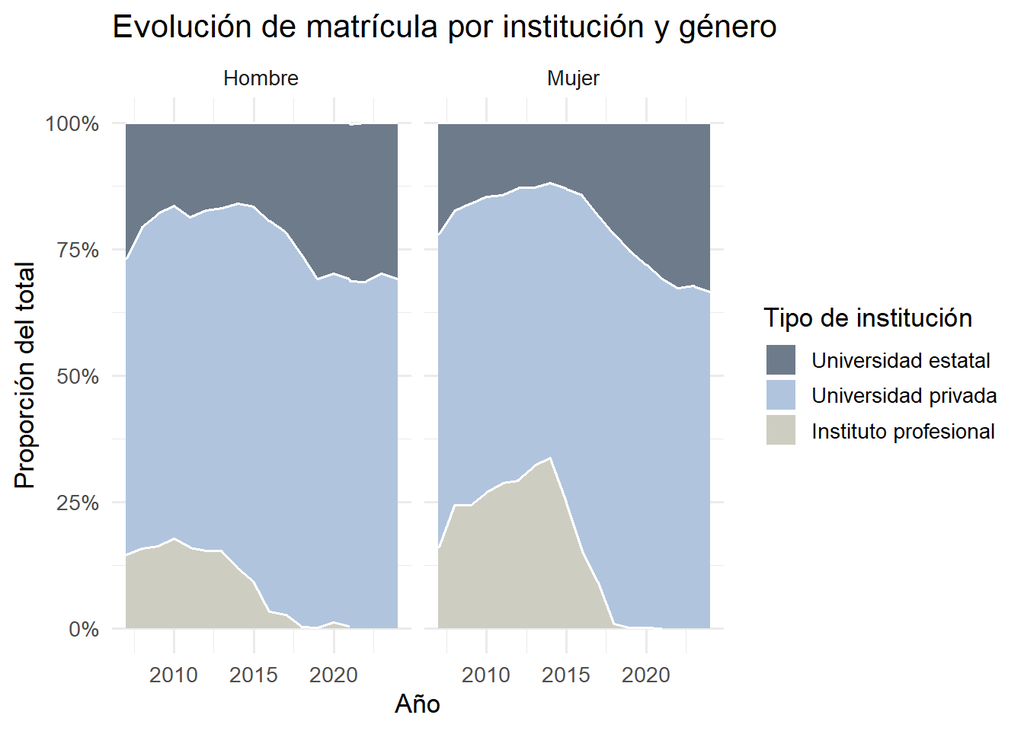

### Figura 13

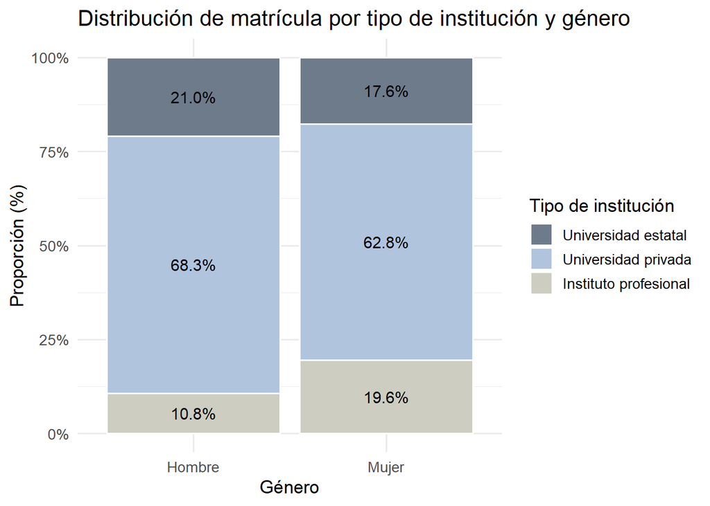

### Figura 14

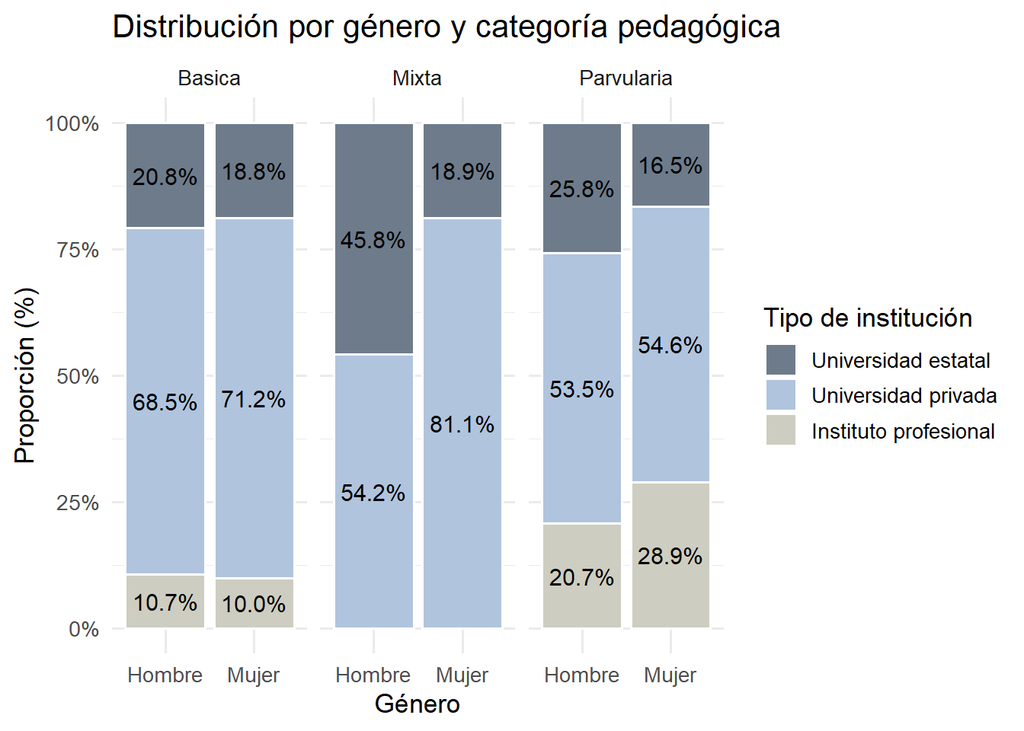

## Base 3 MINEDUC docentes

El análisis del ejercicio docente se basa en los episodios laborales registrados entre quienes ingresan al sistema escolar tras cursar pedagogía. La base incluye 253.679 episodios de ejercicio docente observados durante el período analizado, correspondientes a 28.020 hombres y 225.659 mujeres.

### Figura 15

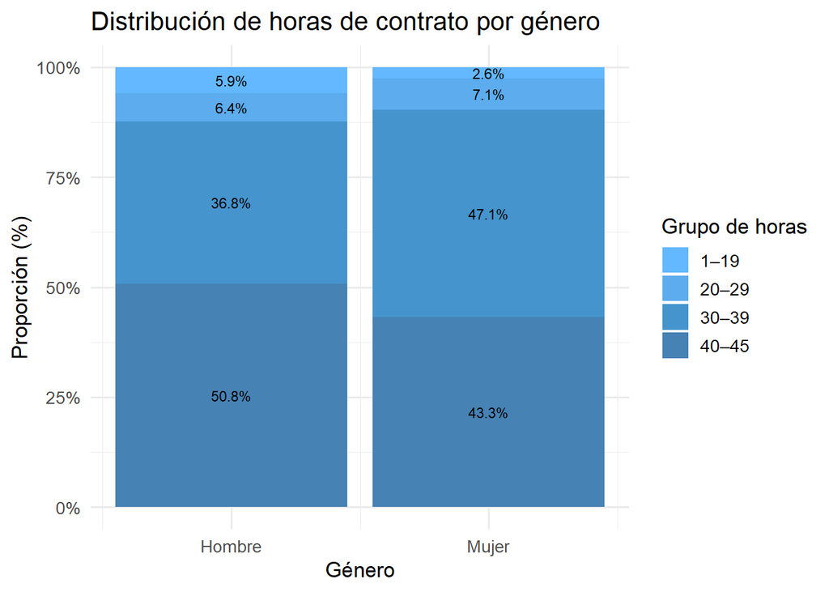

### Figura 16

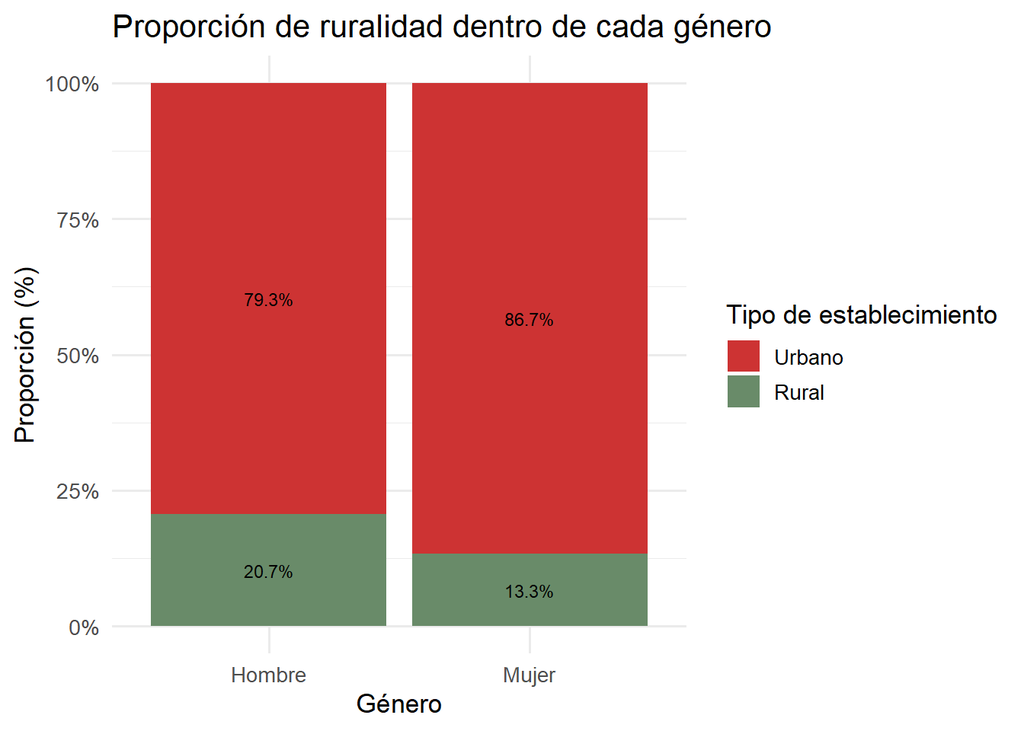

### Figura 17

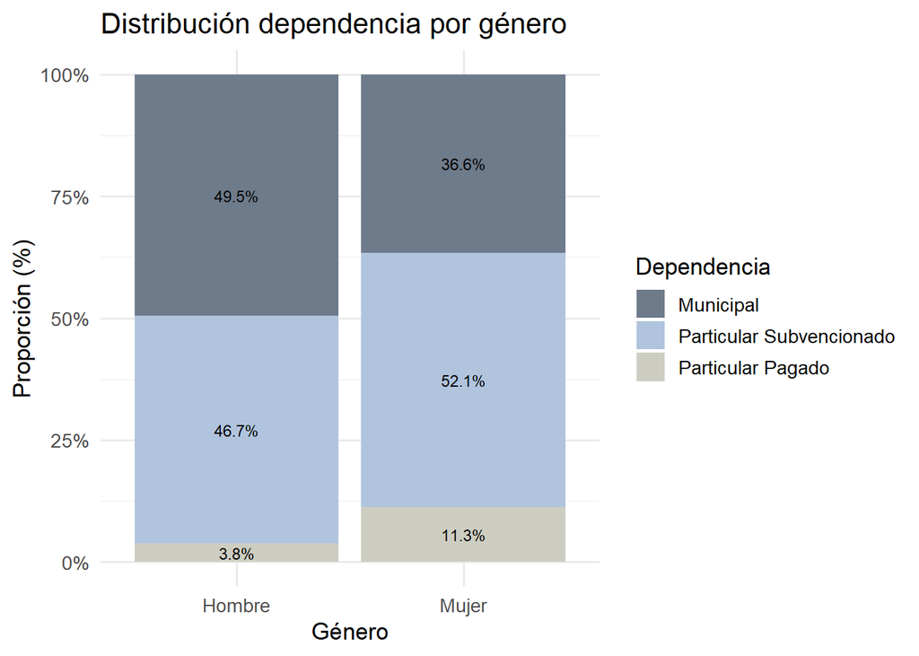

### Figura 18

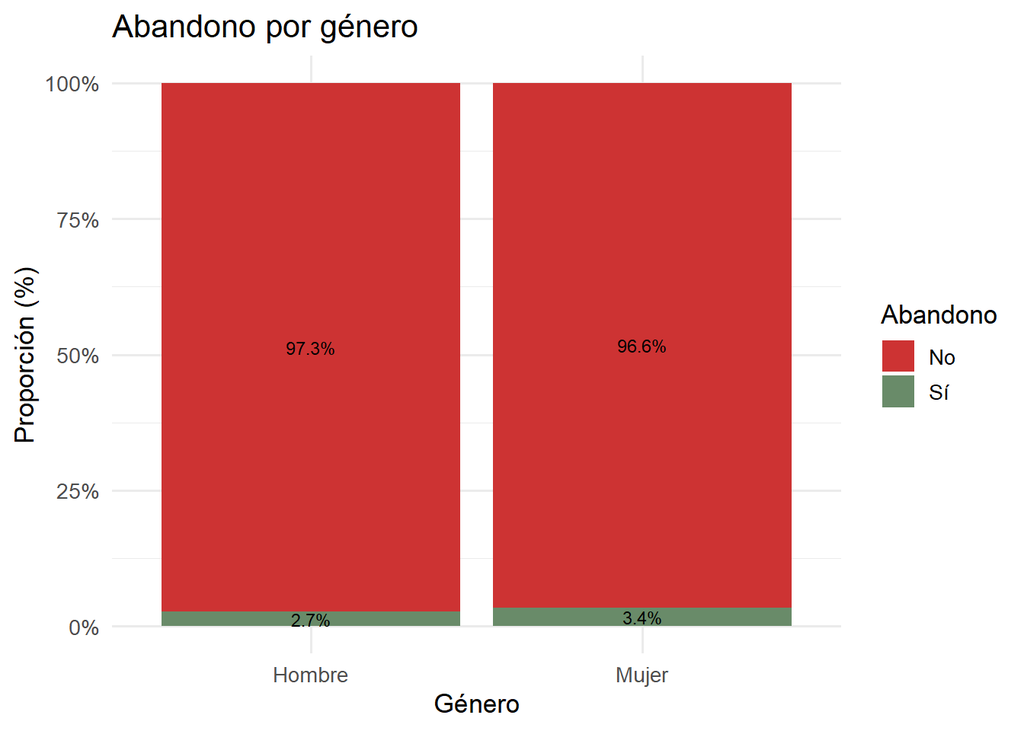

### Figura 19

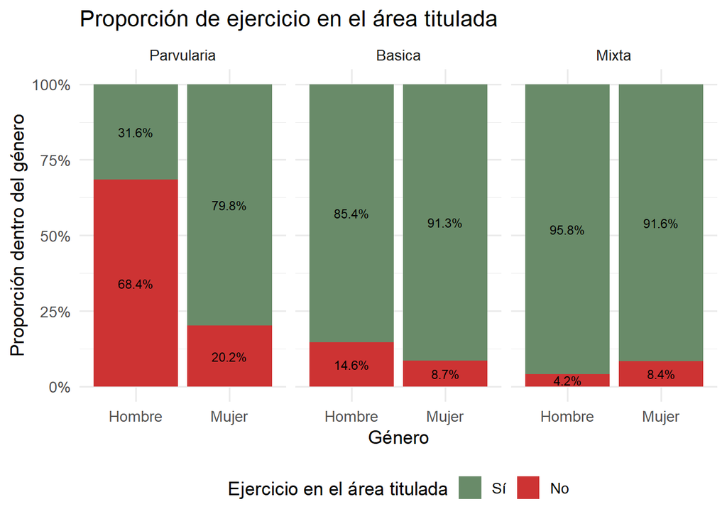

### Figura 20

[interactive chart not shown]

### Figura 21

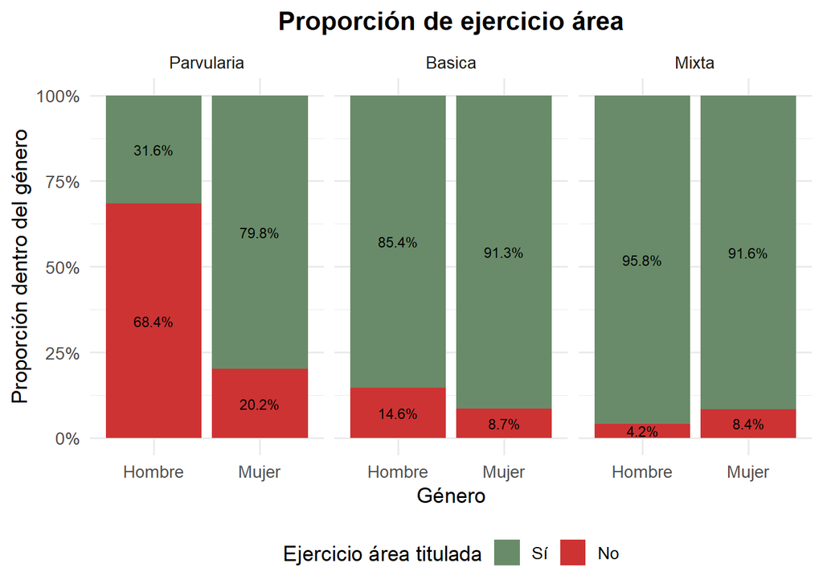

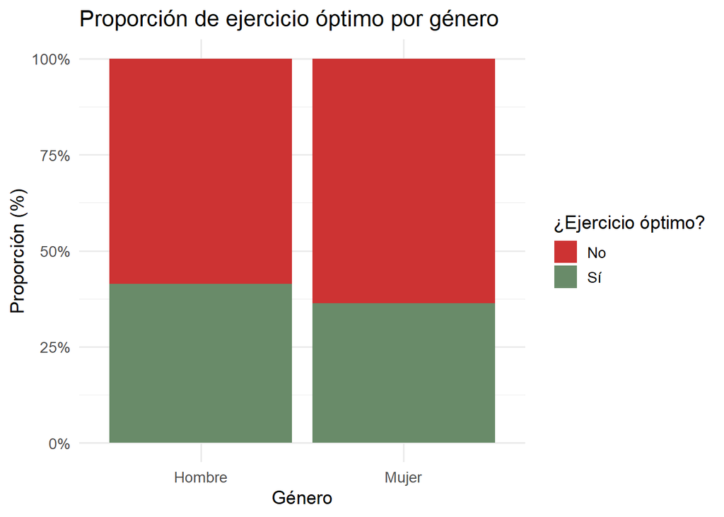

### Figura 22

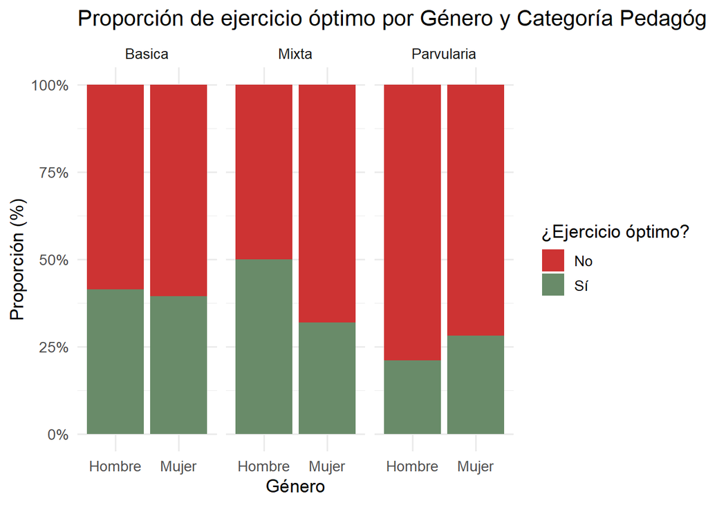

## Información relevante

Este estudio se desarrolla en el marco de una tesis de Magíster en Ciencias Sociales de la Universidad de Chile y se vincula al proyecto Fondecyt Regular N° 1240753 ¿Por qué tan pocos? de la Universidad de los Andes y financiado por la Agencia Nacional de Investigación y Desarrollo (ANID).